# Relationships Between a Child’s Social, Family, and Neighborhood & thier Mental Health Concerns

BINF620

A Manning Smith

12/15/2024

# Abstract

This study utilizes the 2022 National Survey of Children’s Health to examine the complex interactions between social, family, and personal factors influencing mental health concerns (MHC) among youth aged 6-17. Utilizing a comprehensive data set, the research employed logistic regression models to investigate potential predictors of mental health outcomes.

This research contributes to the growing understanding of youth mental health by highlighting the multifaceted nature of mental health concerns and identifying critical areas for further investigation. The findings highlight the importance of comprehensive approaches to understanding and supporting adolescent mental health in the post-pandemic landscape.

There were still multiple variable interactions that showed promising results. Sex was also a significant factor. Another factor was physical activity and the number of after school activities. The other two obvious interactions were being bullied and whether one was being picked on for gender identity or sexuality issues. These factor should be explore further. The aim of the neural network was to combine these factors into one analysis, but not enough success was found.

Though this research may not have been a publishing success, may lessons were learned and future research viability was formed on the basis of the predictors selected.

# Background

With a Global Pandemic behind us and mental health concerns (MHC) on the rise, researchers have intensified their focus on understanding the various social and family impacts experienced by children and adolescents during and after this unprecedented period. Based on data from 2021-2022, reported by the CDC 10% of children ages 3-17 had current, diagnosed anxiety. Moreover, 4% of children ages 3-17 had current, diagnosed depression. The rates grow when you examine teen groups specifically, 21% of teens reported symptoms of anxiety in the past two weeks and 17% reported symptoms of depression in the past two weeks.

This paper aims to explore the various impacts of one’s childhood in shaping the mental health outcomes of children and adolescents. Using data from the 2022 National Survey of Children Health (NSCH) and the application of different statistical methods and neural networks to explore interactions between our selected variables, to identify key predictors that could positively impact the mental health of an individual.

# Study Design

Building upon this foundation, we are offering a robust and data-driven perspective on MHC among youth, outlining the statistical methodologies used to investigate these relationships.

## Aims

The goal of this research it to utilized our identified predictors and their association depression and anxiety in children and adolescents, ages 6-17. Our analyses are based on the 2022 NSCH Survey data and do not include clinical diagnoses or longitudinal evidence.

Furthermore: - To examine how different family dynamics, social factors, and childhood experiences impact MHC. - To examine the severity associated to different MHC. - To explore the performance of the neural networks in predicting MHC.

## Data Exploration & Population Selection

The 2022 NSCH Survey is completed by parents/caregivers of children and able youth, containing 900+ data points. For the purposes of this research roughly 50 variables were selected for further analysis with a subset of about 20 variables utilized in the subsequent models.

Our selected population is children and adolescents, ages 6-17; these records can easily be sorted by the variable `age3_22` divided into 3 groups 0-5: group 1, 6-11: group 2, and 11-17: group 3. For our purposed we have filtered the data on group 2 and 3, reflecting our research interest.

There is no filter removing any specific race, but further analysis is needed to understand how the different selected predictors may vary among race subsequently impact the prediction of our outcome variable.

There are a various number of filters filtering out missing values as described in the independent variables section. The resulting sample was comprised of $19,039$ observations, with a binomial distribution centered around a mean age of approximately $12$ years old. This age range represents a critical period for social and mental development and is particularly significant due to its heightened vulnerability to emotional instability.

## Split and Train Data

```r
n <- nrow(modelData)
train_size <- floor(0.7 * n)
train_indices <- sample(seq_len(n), train_size)

train_data <- modelData[train_indices, ]
test_data <- modelData[-train_indices, ]
test_data$MHealthConcern <- factor(test_data$MHealthConcern)
train_data$MHealthConcern <- factor(train_data$MHealthConcern)
test_data$K8Q35<- as.numeric(as.character(test_data$K8Q35))
train_data$K8Q35 <- as.numeric(as.character(train_data$K8Q35))
```

We will utilize `train_data` in all models and then `test_data` to test the results of our model.

With the selected population and train split decided we can work to utilize our different statistical methods to analyze the strength of evidence in the predictive power of our statistical methods.

# Statistical Analysis

To ensure the viability of the chosen model, an initial logistic regression was performed to evaluate the predictive strength of the selected variables. This foundation will contribute to the selection of a model for a neural network to learn the relationships between predictors and mental health outcomes.

## Response Variable - Mental Health Concern

The selected variables of interest are depression and anxiety. These variables are recorded in a question as “Has a doctor or other health care provider EVER told you that this child has?…Anxiety Problems? or …Depression?”. Followed by, “If yes, does this child CURRENTLY have the condition?” The final question asks for a level of severity provided by 1 = Mild, 2 = Moderate, 3 = Severe.

For our research focus, we utilized three different outcome variables encoded from different reporting variables for depression and anxiety.

- `MHealthConcern`, a binary variable encoded as:
  $$\begin{align*}
  0 &= \text{`K2Q33B` or `K2Q32B`} = 2 \text{('No')} \\
  1 &= \text{`K2Q33B` or `K2Q32B`} = 1 \text{('Yes')}
  \end{align*}$$
- `MHealthScore`, a numerical categorical variable encoded as:
  $$\begin{align*}
  0 &= \text{`K2Q33A` or `K2Q32A`} = 2, &\text{ No reported
  depression or anxiety} \\
  1 &= \text{`K2Q33A` or `K2Q32A`} = 1, &\text{ Reported
  depression or anxiety} \\
  2 &= \text{`K2Q33B` or `K2Q32B`} = 1, &\text{ Currently has
  depression or anxiety} \\
  3 &= \text{`K2Q33B` and `K2Q32B`} = 1, &\text{ Currently has
  depression and anxiety}
  \end{align*}$$
  This variable is helpful to identify differences between individuals who once had a MHC vs those that may or may not currently have a MHC.
- `MHealthScorePlus`, a numerical score variable encoded as:
  $$\begin{align*}
  &= \text{'MHealthConcern'} + \text{'K2Q33C'} +
  \text{'K2Q32C'}
  \end{align*}$$
  This variable takes into account the severity of the MHC. The max score for this variable is 9 being that an individual currently has depression and anxiety and the severity of their depression and anxiety are listed as Severe.

Our predictor variables will allow us to predict our main outcome variable being the binary outcome for individuals currently experiencing depression or anxiety. This multi-level approach ensures a comprehensive understanding of how various predictors contribute to depression and anxiety in children and adolescents.

## Independent Variables

There are various factors that can impacts ones mental health. Stress is a big factor that contributes to ones’ mental health. Adverse childhood experiences, family dynamics, social environments, and neighborhood dynamics are all forms that stress can develop and contribute to mental health concerns. Indicators such as parental MHC, emotional support providers, adverse community and family events, and household experiences all contribute to perceived stress and MHC.

Our variables of interest are listed below and their detailed descriptions can be found in the dictionary.

```
"SC_AGE_YEARS", "HHCOUNT", "BORNUSA", "K8Q35", "ACE12",
"PHYSACTIV", "age3_22", "sex_22", "MotherMH_22",
"FatherMH_22", "ScreenTime_22", "ACEct11_22", "ACE4ctCom_22",
"SC_RACE_R", "bully_22", "bullied_22", "AftSchAct_22",
"EventPart_22", "mentor_22", "ShareIdeas_22",
"ACE6ctHH_22", "NbhdSupp_22", "NbhdSafe_22", "FAMILY_R"
```

## Initial Models

In alignment with our themes in the variables, 3 different smaller models were formed to prove viability in proceeding with a neural network for the main model.

The first model takes into account neighborhood impacts, activities, and emotional support. This model was formed with the outcome variable being `MHealthConcern`, utilizing logistic regression to predict a binary response variable.

**Model 1:** `MHealthConcern ~ HHCOUNT+PHYSACTIV+K8Q35+mentor_22+ShareIdeas_22+ScreenTime_22+ACE4ctCom_22+AftSchAct_22+NbhdSupp_22+NbhdSafe_22`

The second model examines the impacts of family and childhood history.

**Model 2:** `MHealthConcern ~ HHCOUNT+BORNUSA+K8Q35+ACE12+SC_AGE_YEARS+SC_RACE_R+bully_22+bullied_22+AftSchAct_22+EventPart_22+mentor_22+ShareIdeas_22+ FAMILY_R`

The third model took into account adverse childhood events and social relationship with peers and/or friends.

**Model 3:** `MHealthConcern ~ HHCOUNT+BORNUSA+K8Q35+ACE12+bully_22+bullied_22+AftSchAct_22+EventPart_22+mentor_22+ShareIdeas_22`

The final model is a combination of all the selected predictor variables.

**Model 4:** `MHealthConcern ~ HHCOUNT+BORNUSA+K8Q35+ACE12+PHYSACTIV+SC_AGE_YEARS+sex_22+MotherMH_22+FatherMH_22+ScreenTime_22+ACEct11_22+ACE4ctCom_22+Sc_RACE_R+bully_22+bullied_22+AftSchAct_22+EventPart_22+mentor_22+ShareIdeas_22+ACE6ctHH_22+NbhdSupp_22+NbhdSafe_22+FAMILY_R`

The results from these methods are summarized below:

## Model Selection

```r
# Table 1 | Table 0.0 --> Logistic Regression Results
knitr::kable(logisticReg_metrics, col.names = c("Model", "Metric", "Value"), caption = "Table 1.1 | Logistic Regression Model Performance Metrics")
```

Table 1.1 | Logistic Regression Model Performance Metrics

| Model | Metric | Value |
| --- | --- | --- |
| Model 1 | Accuracy | 0.8536415 |
| Model 1 | Sensitivity | 0.0000000 |
| Model 1 | Specificity | 1.0000000 |
| Model 1 | False Positive Rate (FPR) | 0.0000000 |
| Model 2 | Accuracy | 0.8553922 |
| Model 2 | Sensitivity | 0.0454545 |
| Model 2 | Specificity | 0.9942576 |
| Model 2 | False Positive Rate (FPR) | 0.0057424 |
| Model 3 | Accuracy | 0.8569678 |
| Model 3 | Sensitivity | 0.0933014 |
| Model 3 | Specificity | 0.9878999 |
| Model 3 | False Positive Rate (FPR) | 0.0121001 |
| Model 4 | Accuracy | 0.8590686 |
| Model 4 | Sensitivity | 0.1303828 |
| Model 4 | Specificity | 0.9840033 |
| Model 4 | False Positive Rate (FPR) | 0.0159967 |
| Final Model | Accuracy | 0.8592437 |
| Final Model | Sensitivity | 0.1291866 |
| Final Model | Specificity | 0.9844135 |
| Final Model | False Positive Rate (FPR) | 0.0155865 |

Upon inspection of the model the variables that had the best results in the performance of these models were selected to form the final model to be utilized in the neural network. The selected model was:

**Final Model:** `MHealthConcern ~ SC_AGE_YEARS * sex_22 * SC_RACE_R + PHYSACTIV * AftSchAct_22 * ACEct11_22 + ACE4ctCom_22 + MotherMH_22 * FatherMH_22 + FAMILY_R + HHCOUNT + bullied_22 + ACE12 + ShareIdeas_22 + mentor_22`

## Neural Network

We will utilize the final model described above; however, the interactions were not included in the neural network. To ensure a model that converges and runs pretty easily we will perform a simple neutral network using the basic parameters.

Instead of scaling the data, we utilized a method that expands our factored variables into specific binary columns. This will allow the model to work more efficiently and effectively.

```r
# Final Model
n <- nrow(modelData)
train_size <- floor(0.7 * n)
train_indices <- sample(seq_len(n), train_size)

train_data <- modelData[train_indices, ]
test_data <- modelData[-train_indices, ]
train_data <- train_data[, model4_filter]
test_data <- test_data[, model4_filter]
train_data[factor_Variables] <- lapply(train_data[factor_Variables], as.factor)
test_data[factor_Variables] <- lapply(test_data[factor_Variables], as.factor)
train_data <- dummy_cols(train_data,
                         remove_selected_columns = TRUE,
                         remove_first_dummy = TRUE)
test_data <- dummy_cols(test_data,
                        remove_selected_columns = TRUE,
                        remove_first_dummy = TRUE)
model_final_string <- paste(colnames(train_data), collapse = " + ")
model_final_string <- gsub("MHealthConcern_1", "", model_final_string)
model_final_string <- as.formula(paste("MHealthConcern_1 ~", model_final_string))

nn_model_final <- neuralnet(model_final_string,
                        data = train_data,
                        linear.output = FALSE,
                        likelihood = TRUE,
                        algorithm = "rprop+",
                        err.fct = "ce")
```

## KMeans

Further analysis was performed due to the limited significance of the neural network. KMeans was performed to sort our data into 2 groups work towards the groups being that we have created for our mental health concerns.

# Results

## Major Findings

In terms of the neural network. There seems to be potential in this method, but do to time and study constrains this analysis was not successful at performing any predictability. Code has been provided that can be further adapted for future success, but at its current state there was no success in the use of the neural network.

## Tables and Figures

[figure not shown]

```r
# Figure 1 | Figure 2.1 --> Health Score by Age Group Filled by Score
grid.arrange(fig1)
```

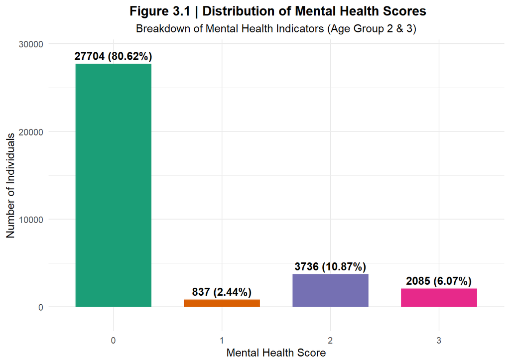

```r
# Figure 2 | Figure 3.1 --> Mental Health Score Proportion filtered by Age Group 2/3
grid.arrange(fig2)
```

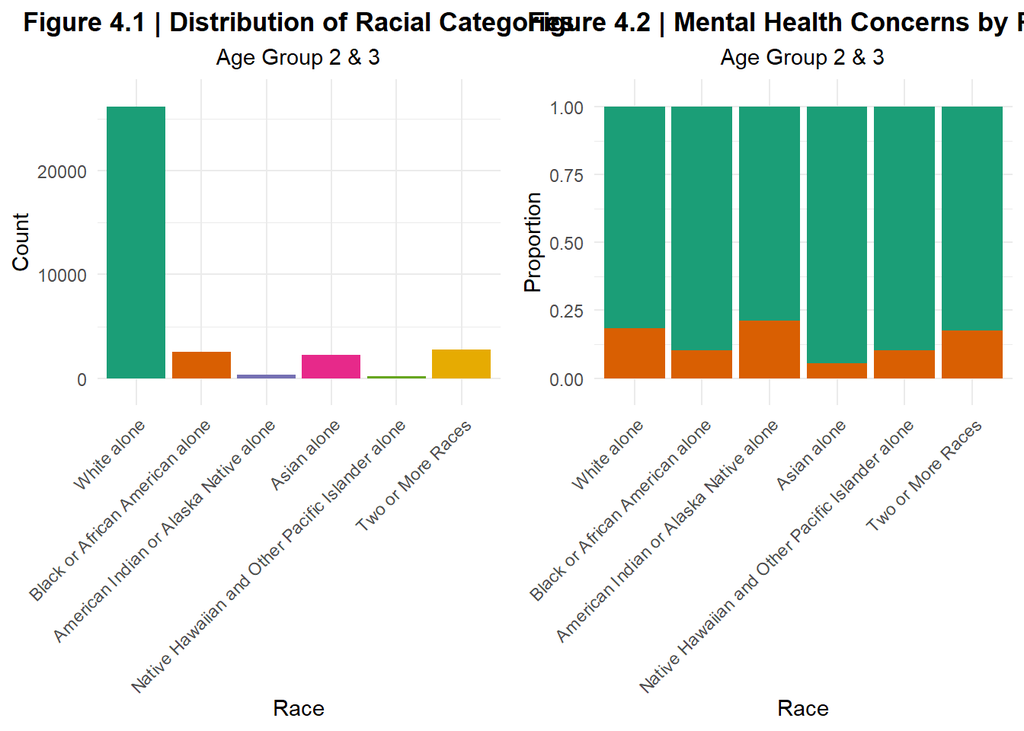

```r
# Figure 3 | Figure 4.0 --> Mental Health Score by Race
grid.arrange(fig3_1, fig3_2, ncol = 2, nrow = 1)
```

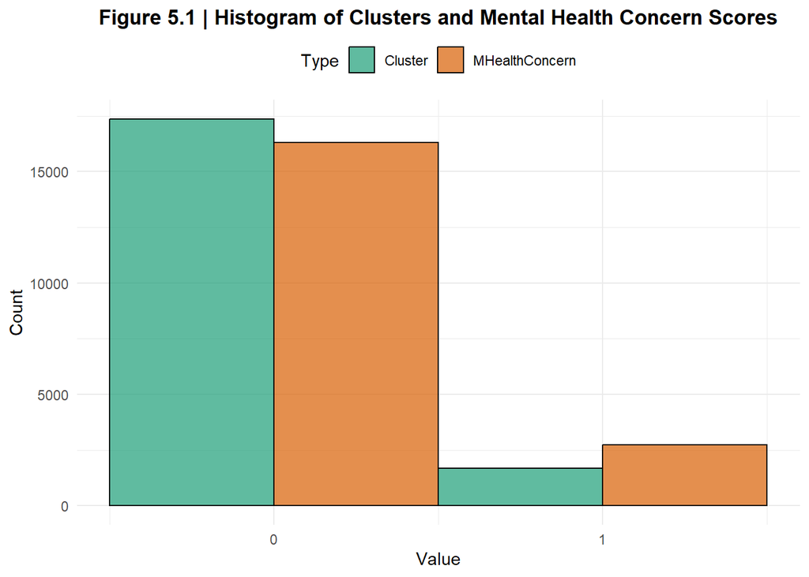

```r
# Figure 5 | Figure 5.1 --> Kmeans results
grid.arrange(fig5)
```

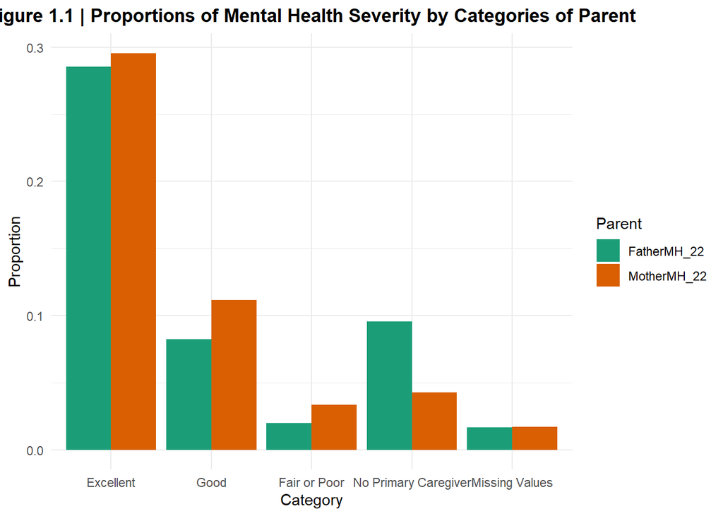

```r
# Figure 6 | Figure 1.1 --> Mother/Father Mental Health History
grid.arrange(fig6)
```

# Conclusions

Overall, this research aimed to explore different social, family, and neighborhood factors that can influence the current status of one’s mental health, as expressed by either depression or anxiety. Various models were tested utilizing logistic regressions. These results signified feasibility for further analysis; however, due to research and time constraints further analyses were not successful.

The use of a neural network was attempted, but no successful network converged for proved significant evidence. Further research is needed on this front to suggest the predictability of our variables in predicting mental health concerns.

Thought there were not ground breaking findings, there were some interactions between selected variables that warren further exploration. In the models, sex was also a significant factor. Another factor was physical activity and the number of after school activities. The other two obvious interactions were being bullied and whether one was being picked on for gender identity or sexuality issues. These factor should be explore further. The aim of the neural network was to combine these factors into one analysis, but not enough success was found.

# References

- https://www.cdc.gov/children-mental-health/data-research/index.html